# 51 A dozen minima for a parabola

This section uses these packages:

```julia
using SymPy
using Plots
using Roots
```

In the March 2003 issue of the College Mathematics Journal, Leon M Hall posed 12 questions related to Figure 51.1. The figure shows $f(x) = x^2$, the tangent line at $P = (a, f(a))$ (for $a > 0$), and the *normal* line at $(a, f(a))$. The questions all involve finding the value $a$ which minimizes a related quantity that has been previously discussed.

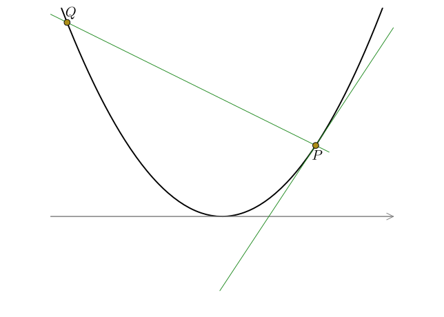

Figure 51.1: A parabola with tangent and normal line at point $P$

The solutions are a bit of fun. To approach them, we set up some variables to work symbolically:

```julia
@syms a::positive x::real
f(x) = x^2
fp(x) = 2x
m = fp(a)
mᴵ = - 1/m
tl = f(a) + m * (x - a)
nl = f(a) + mᴵ * (x - a)
zs = solve(f(x) ~ nl, x)
q = only(filter(!=(a), zs))
```

$- a - \frac{1}{2 a}$

The first question is simply:

> 1a. The $y$ coordinate of $Q$

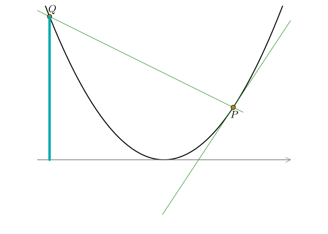

Figure 51.2: Emphasis of $y$ coordinate of $Q$

The value is $f(q)$

```julia
yvalue = f(q)
```

$\left(- a - \frac{1}{2 a}\right)^{2}$

To minimize we solve for critical points:

```julia
cps = solve(diff(yvalue, a), a)
```

$\left[\begin{smallmatrix}\frac{\sqrt{2}}{2}\end{smallmatrix}\right]$

The lone critical point must be at a minimum. (Given the geometry of the problem, as $a$ goes to $\infty$ the height does too, and as $a$ goes to $0$ the height will also go to $\infty$. This can also be seen analytically, as $q = -a - 1/(2a)$ which goes to $-\infty$ when $a$ heads to $0$ or $\infty$.)

**NoteWe hide the code**

In the remaining examples we don’t immediately show the code to describe the value to optimize; it is hidden in a collapsed block.

> 1b. The length of the line segment $PQ$

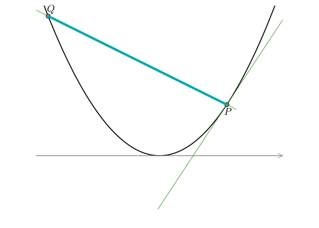

Figure 51.3: Emphasis of line segment connecting $P$ and $Q$

```julia
lseg = sqrt((f(a) - f(q))^2 + (a - q)^2);
```

> 2a. The horizontal distance between $P$ and $Q$

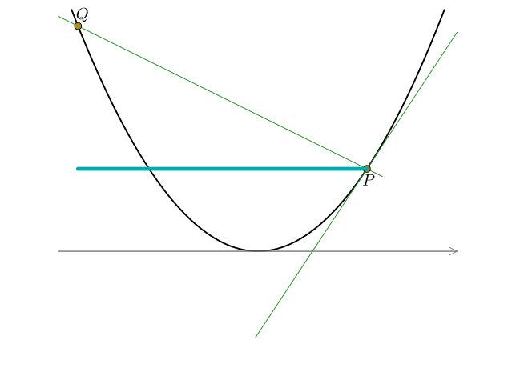

Figure 51.4: Emphasis of horizontal distance between $P$ and $Q$

```julia
hd = a - q;
```

> 2b. The area of the parabolic segment

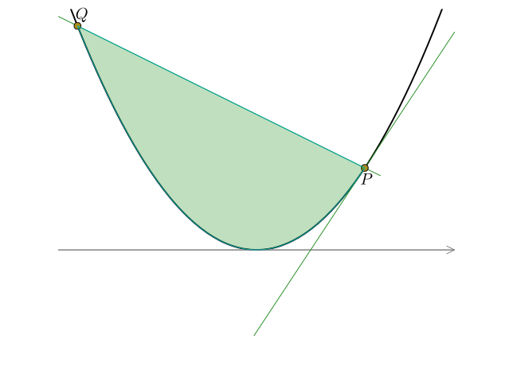

Figure 51.5: Emphasis of parabolic segment formed by the normal line

```julia
A = simplify(integrate(nl - f(x), (x, q, a)));
```

> 2c. The volume of the rotated solid formed by revolving the parabolic segment around the vertical line $k$ units to the right of $P$ or to the left of $Q$ where $k > 0$.

```julia
@syms k::nonnegative
V = simplify(integrate(2PI*(nl-f(x))*(a - x + k),(x, q, a)));
```

> 3. The $y$ coordinate of the centroid of the parabolic segment

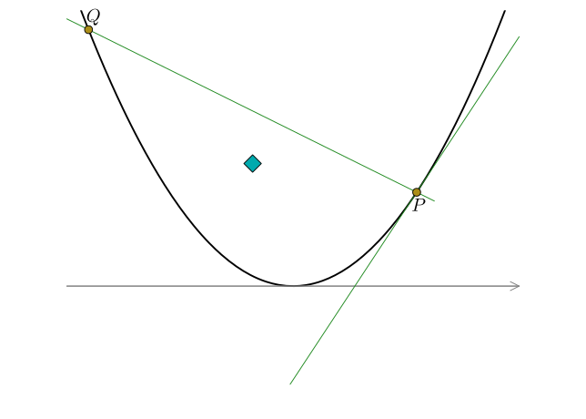

Figure 51.6: Emphasis of centrood of the parabolic segment formed by the normal line

We warm up with the $x$ coordinate, given by:

```julia
xₘ = integrate(x * (nl - f(x)), (x, q, a)) / A
simplify(xₘ)
```

$- \frac{1}{4 a}$

a fact noted by the author.

```julia
yₘ = integrate( (1//2) * (nl^2 - f(x)^2), (x, q, a)) / A
yₘ = simplify(yₘ);
```

> 4. The length of the arc of the parabola between $P$ and $Q$

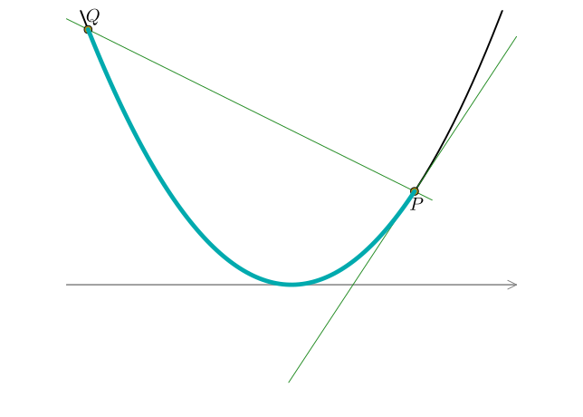

Figure 51.7: Emphasis of arc-length along parabola

```julia
L = integrate(sqrt(1 + fp(x)^2), (x, q, a));
```

> 5. The $y$ coordinate of the midpoint of the line segment $PQ$

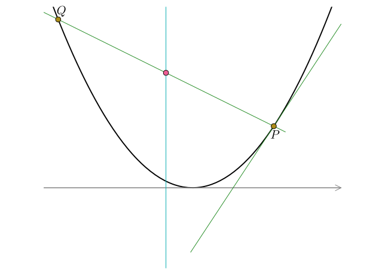

Figure 51.8: Emphasis of $y$ intercept for line $PQ$

```julia
mp = nl(x => (a + q)/2);
```

> 6. The area of the trapezoid bound by the normal line, the $x$-axis, and the vertical lines through $P$ and $Q$.

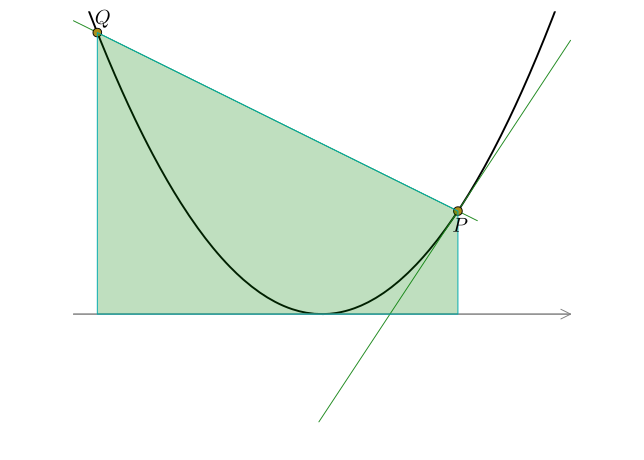

Figure 51.9: Emphasis of traapezoid bounded by the normal line

```julia
trap = 1//2 * (f(q) + f(a)) * (a - q);
```

> 7. The area bounded by the parabola and the $x$ axis and the vertical lines through $P$ and $Q$

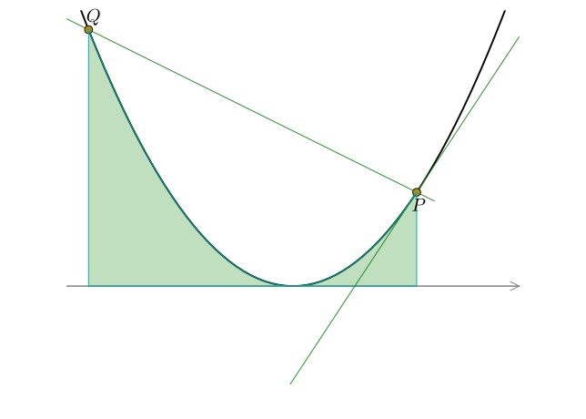

Figure 51.10: Area under the parabola between $P$ and $Q$

```julia
pa = integrate(x^2, (x, q, a));
```

> 8. The area of the surface formed by revolving the arc of the parabola between $P$ and $Q$ around the vertical line through $P$

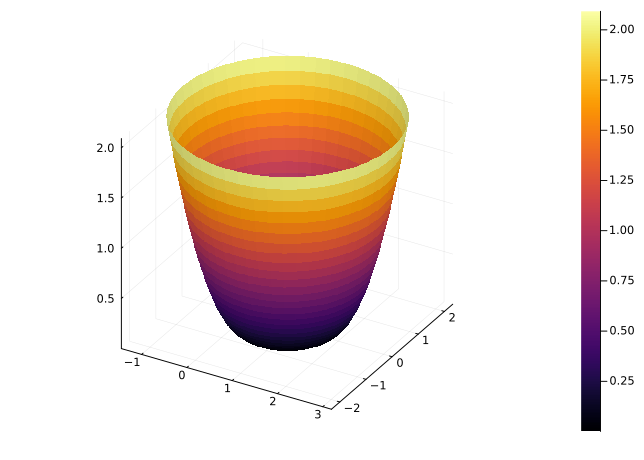

Figure 51.11: Surface area formed by revolving arc through $P$

```julia
# use parametric and  2π ∫ u(t) √(u'(t)^2 + v'(t)^2) dt
uu(x) = a - x
vv(x) = f(a - uu(x))
SA = 2PI * integrate(uu(x) * sqrt(diff(uu(x),x)^2 + diff(vv(x),x)^2), (x, q, a));
```

> 9. The height of the parabolic segment (i.e. the distance between the normal line and the tangent line to the parabola that is parallel to the normal line)

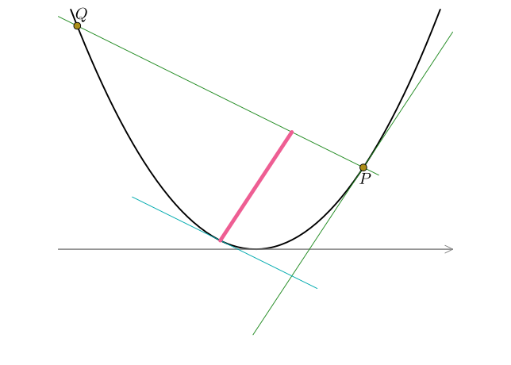

Figure 51.12: Emphasis of the height of the parabolic segment

```julia
# find b through mean value theorem,
# then solve for point of intersection
b = only(solve(diff(f(x),x) ~ -1/fp(a), x))
b′ = only(solve(f(b) + fp(a)*(x-b) ~ nl, x))
segment_height = sqrt((b-b′)^2 + (f(b) - nl(x=>b′))^2);
```

> 10. The volume of the solid formed by revolving the parabolic segment around the $x$-axis

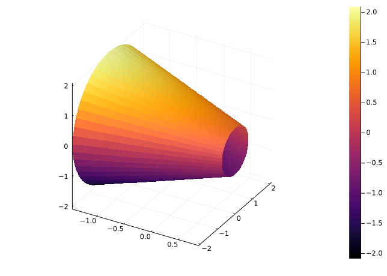

Figure 51.13: Volume formed by revolving parabolic segment around $x$ axis

```julia
Vₓ = integrate(pi * (nl^2 - f(x)^2), (x, q, a));
```

> 11. The area of the triangle bound by the normal line, the vertical line through $Q$ and the $x$-axis

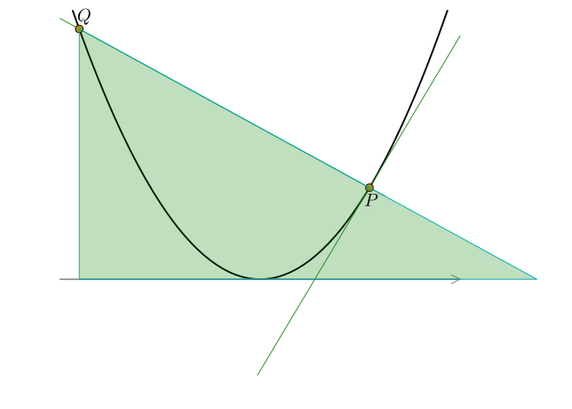

Figure 51.14: Emphasis of triangle formed along normal line

```julia
triangle = 1/2 * f(q) * (a - f(a)/(-1/fp(a)) - q);
```

> 12. The area of the quadrilateral bound by the normal line, the tangent line, the vertical line through $Q$ and the $x$-axis

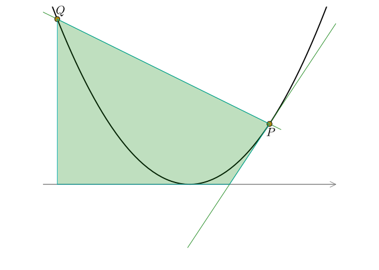

Figure 51.15: Emphasis of quadrilateral bounded by normal line and tangent line

```julia
# use shoelace formula
# (1/2) * (x₁⋅y₂-y₁⋅x₂ + x₂⋅y₃-y₂⋅x₃ + x₃⋅y₄-y₃⋅x₄ + x₄⋅y₁-y₄⋅x₁)
tl₀ = a - f(a) / fp(a)
x₁, x₂, x₃, x₄ = (a, q, q, tl₀)
y₁, y₂, y₃, y₄ = (f(a), f(q), 0, 0)
quadrilateral = (1/2) * (x₁*y₂ - y₁*x₂ + x₂*y₃ - y₂*x₃ + x₃*y₄ - y₃*x₄ + x₄*y₁ - y₄*x₁);
```

The answers appear here in sorted order, some given as approximate floating point values:

```julia
article_answers = (1/(2sqrt(2)), 1/2, sqrt(3/10), 0.558480, 0.564641,
                   0.569723, 0.574646,
                   1/sqrt(3), 1/8^(1/4), 1/6^(1/4), .644004, 1/sqrt(2))
```

```
(0.35355339059327373, 0.5, 0.5477225575051661, 0.55848, 0.564641, 0.569723, 0.574646, 0.5773502691896258, 0.5946035575013605, 0.6389431042462724, 0.644004, 0.7071067811865475)
```